# Practice Activity Week 1

```r
library(tidyverse)
```

## Quarto

First, let’s make sure you know how to use Markdown formatting to style a Quarto document.

1. **Make this text bold.**
2. *Make this text italicized.*
3. Make these items into a bullet point list:
- Apples
- Bananas
- Potatoes
4. Edit the YAML to remove warning messages from being output in the rendered HTML file
5. Using code chunk options, make it so this chunk shows the code but not the output:

```r
2 + 2
```

6. Using code chunk options, make it so the file can still render even though this chunk has an error

```r
2 + a
```

```
Error:
! object 'a' not found
```

## Data Visualization Review

In this class, we will exclusively make visualizations using `ggplot2` and packages developed to be compatible with `ggplot2`. If you are less familiar with plotting in `ggplot2` or it’s been some time since you used this package, I would strongly recommend referencing resources from the data visualization section of this week’s coursework!

The questions below (Questions 7-11) utilize the `mpg` data from the `tidyverse` package.

7. Use side-by-side boxplots to visualize the distribution of `hwy` miles per gallon for each `manufacturer`. **The names of the manufacturers should be easily readable, and your axes should include any necessary information regarding the variables and their units!**

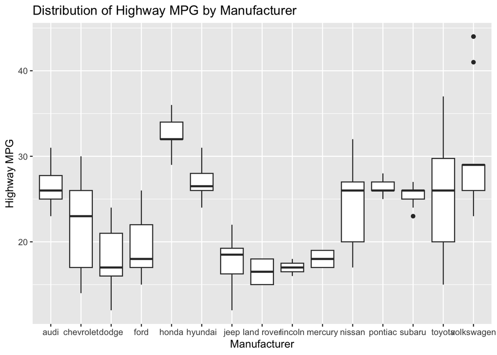

```r
ggplot(data=mpg,aes(x=manufacturer,y=hwy))+
  geom_boxplot()+
  labs(x="Manufacturer",y="Highway MPG",title="Distribution of Highway MPG by Manufacturer")
```

8. Use faceted scatterplots to visualize how the relationship between `hwy` mileage and `cty` mileage has changed over time. **Your axes should include any necessary information regarding the variables and their units!**

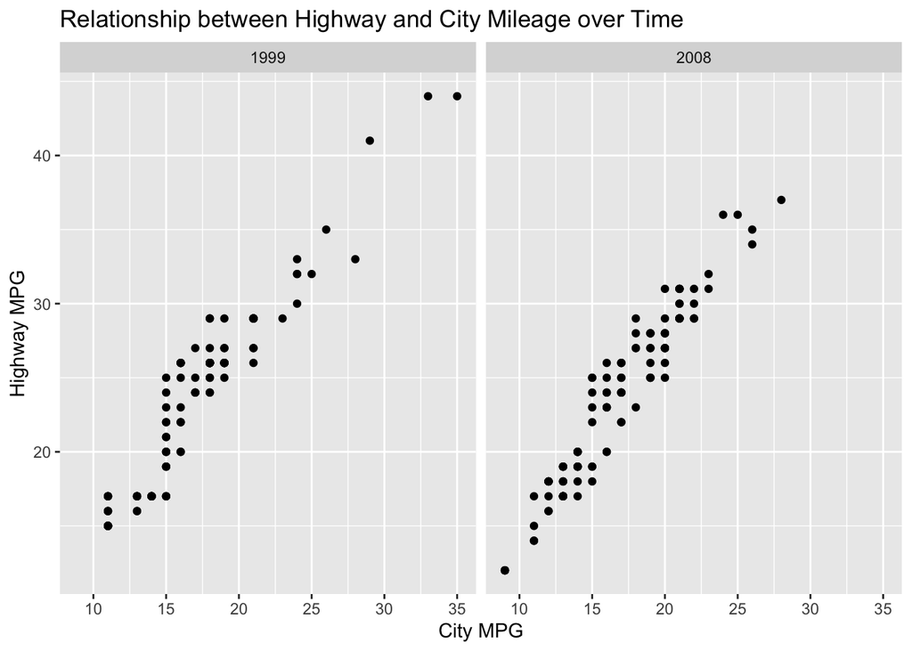

```r
ggplot(data=mpg, aes(x=cty,y=hwy))+
  geom_point()+
  facet_wrap(~year)+
  labs(x="City MPG",y="Highway MPG",title="Relationship between Highway and City Mileage over Time")
```

## Data Wrangling Review

In this class, we will exclusively make use of tools from the `tidyverse` suite of packages to perform our data cleaning and wrangling operations. If you are less familiar with these packages or it’s been some time since you used them, I would strongly recommend referencing the function documentation!

For these problems, we will continue to work with the `mpg` data frame, making various changes to the data to clean it up.

9. The `fl` variable describes the type of fuel for each car, with levels: `p`, `r`, `e`, `d`, and `c`. Do some research into what each of these labels mean! Then, use the `mutate()` and `if_else()` functions to create a new variable (`fuel_type`) with two levels: `petrol` (any car using petrolium-based gas) and `alternative energy` (any car not using petrolium-based gas).

```r
mpg<- mpg %>% mutate(fuel_type=ifelse(fl %in% c("p","r","e","d","c"),
                                      "Gasoline",
                                      "Alternative"))
```

10. The `drv` variable describes if the car has front drive (`f`), rear drive (`r`), or four wheel drive (`4`). Let’s make better labels for these values! Specifically, use the `mutate()` and `recode_values()` to change the `drv` variable to have the following descriptive levels: `front`, `rear`, `four wheel`.

```r
mpg <- mpg %>% mutate(drv =
                        recode(drv,
                               "f"="front",
                               "r"="rear",
                               "4"="four wheel"))
```

11. The `trans` variable contains two pieces of information, (1) the transmission style (`auto` or `manual`) and the specific type of transmission (e.g., `l5`, `m5`, `av`). Using the `separate_wider_delim()` function, create two new variables from `trans`, (1) `trans_type` containing the specific type of transmission of each car (e.g., `l5`), and (2) `trans_style` the style of the transmission (e.g., `auto`). *Hint: You will need to deal with the stray parenthesis!*

```r
mpg <- mpg %>%
  separate_wider_delim(
    trans,
    delim = "(",
    names = c("trans_style", "trans_type")) %>%
  mutate(
    trans_type = str_remove(trans_type, "\\)"))
```

## Getting to know your classmates

12. Find someone who took Stat 331 from a different professor than you. Compare your experiences. Tell me their name and professor. List one or two things that you think you learned more about, and one or two things that they learned more about.

Rayan had Dr.Theobold for 331. He said he had a pretty good experience and that his class did a lot of quarto stuff

13. Find someone in the class who **does not** share your birth month. Tell me their name and birthday, and use R to find out how many days apart your birthdays are.

```r
abs(as.Date("2005-05-14")-as.Date("2005-08-19"))
```

```
Time difference of 97 days
```